# The anlysis of white wine by lin shou bao

# Multivariate Plots Section

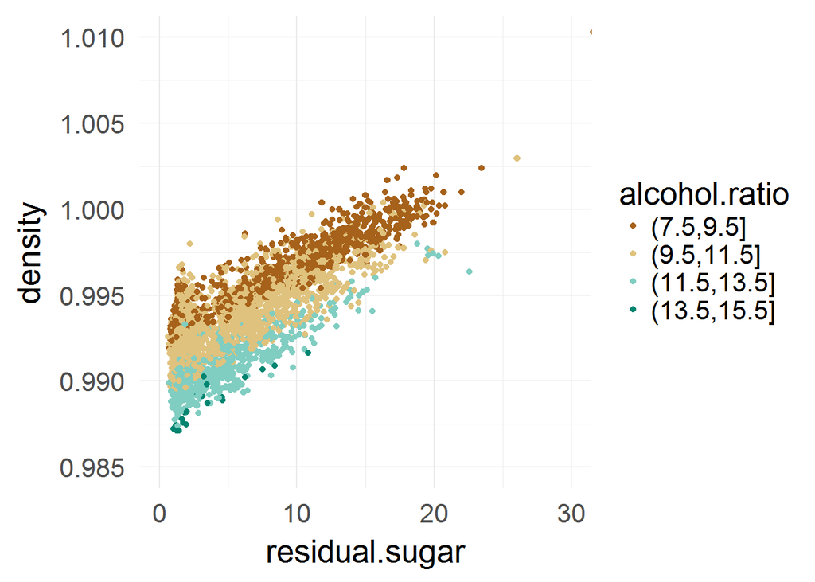

从这张图中更加直观的观察到：酒精含量越高，密度越小；残糖量越多，密度越大。

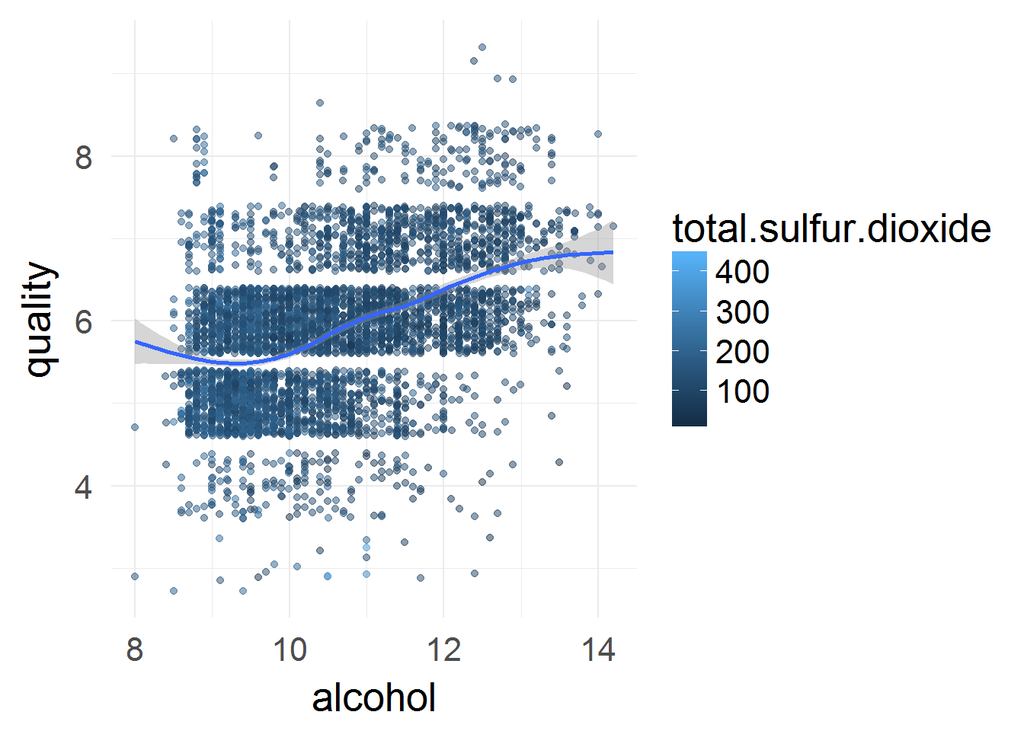

第三变量是连续变量，因此我们很难从多变量分析中，找出他们之间的关系。

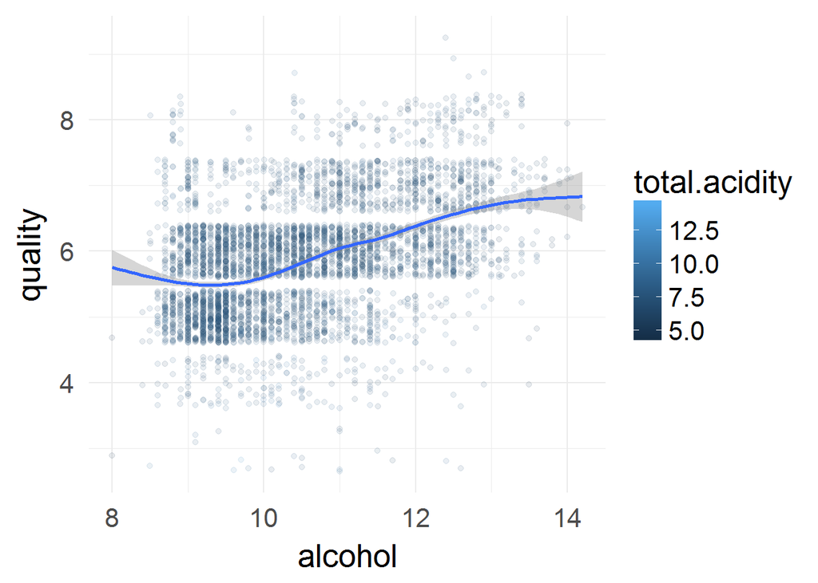

同样的问题，很难发现第三变量与其他变量之间的关系。

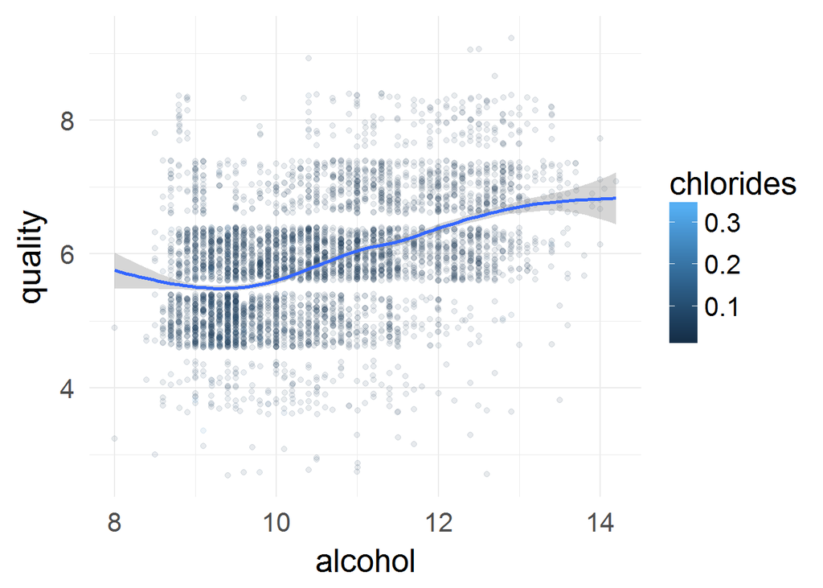

也是同样的问题。

```
##
## Calls:
## m1: lm(formula = I(quality) ~ I(alcohol), data = white_wine)
## m2: lm(formula = I(quality) ~ I(alcohol) + total.acidity, data = white_wine)
## m3: lm(formula = I(quality) ~ I(alcohol) + total.acidity + chlorides,
##     data = white_wine)
## m4: lm(formula = I(quality) ~ I(alcohol) + total.acidity + chlorides +
##     total.sulfur.dioxide, data = white_wine)
##
## ====================================================================
##                            m1         m2         m3         m4
## --------------------------------------------------------------------
##   (Intercept)            2.582***   3.260***   3.536***   3.340***
##                         (0.098)    (0.145)    (0.158)    (0.177)
##   I(alcohol)             0.313***   0.307***   0.291***   0.302***
##                         (0.009)    (0.009)    (0.010)    (0.011)
##   total.acidity                    -0.081***  -0.081***  -0.083***
##                                    (0.013)    (0.013)    (0.013)
##   chlorides                                   -2.459***  -2.519***
##                                               (0.556)    (0.556)
##   total.sulfur.dioxide                                    0.001*
##                                                          (0.000)
## --------------------------------------------------------------------
##   R-squared                  0.2        0.2        0.2        0.2
##   adj. R-squared             0.2        0.2        0.2        0.2
##   sigma                      0.8        0.8        0.8        0.8
##   F                       1146.4      597.6      406.4      306.6
##   p                          0.0        0.0        0.0        0.0
##   Log-likelihood         -5839.4    -5819.6    -5809.8    -5806.8
##   Deviance                3112.3     3087.2     3074.9     3071.1
##   AIC                    11684.8    11647.2    11629.7    11625.6
##   BIC                    11704.3    11673.2    11662.1    11664.6
##   N                       4898       4898       4898       4898
## ====================================================================
```

从计算中，我们把与quality相关的变量加入了线性回归计算，但是得出的结果很惊讶，只能解释20%值的方差。

# Multivariate Analysis

### Talk about some of the relationships you observed in this part of the investigation. Were there features that strengthened each other in terms of looking at your feature(s) of interest?

1.利用多变量分析，更加直观的刚看到密度和酒精、残糖量之间的关系。 2.没有发现相互之间可以加强的特征变量。

### Were there any interesting or surprising interactions between features?

1.density与residual.sugar保持正相关，与alcohol保持负相关。说明density本身就是因变量，值被其他值影响。

### OPTIONAL: Did you create any models with your dataset? Discuss the strengths and limitations of your model.

# Final Plots and Summary

### Plot One

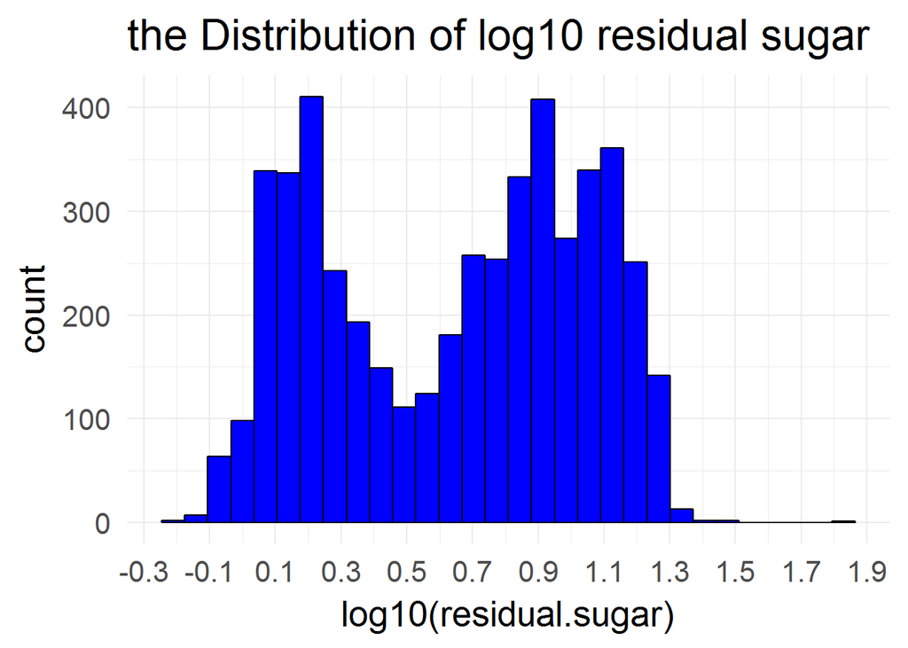

### Description One

对残糖量取对数后，发现直方图是双峰分布，可以看出数据集中残糖量主要集中在0.2和0.9附近。

### Plot Two

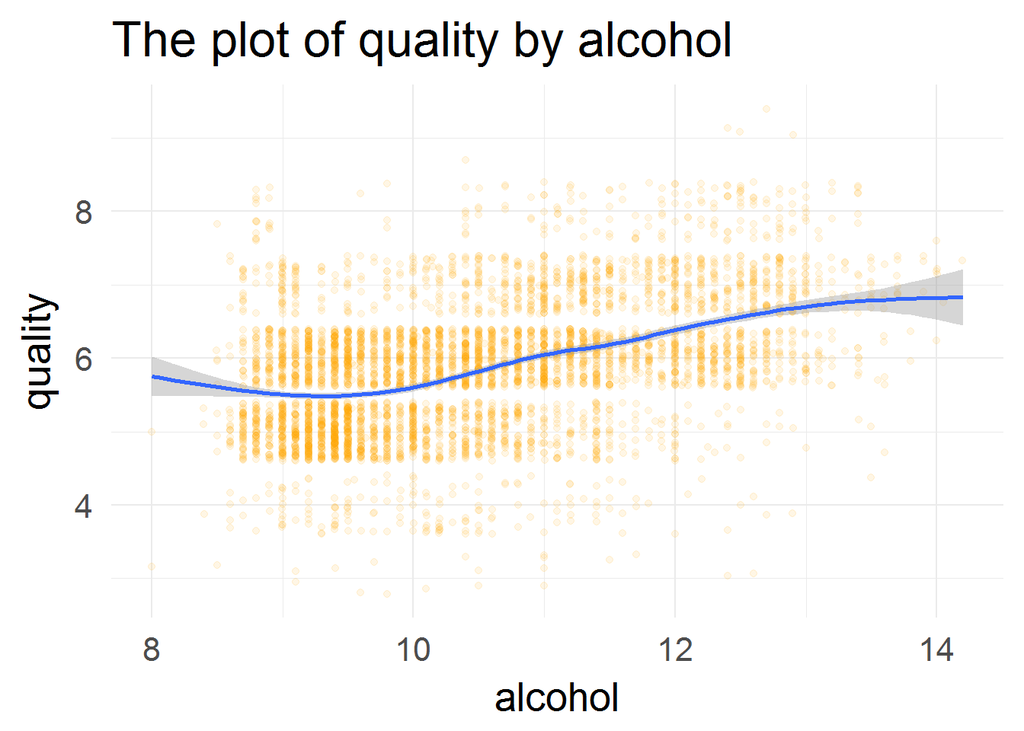

### Description Two

酒精变量与质量变量是唯一的正相关关系，相关系数最大，其他变量都是负相关关系，且表现的很微弱。

### Plot Three

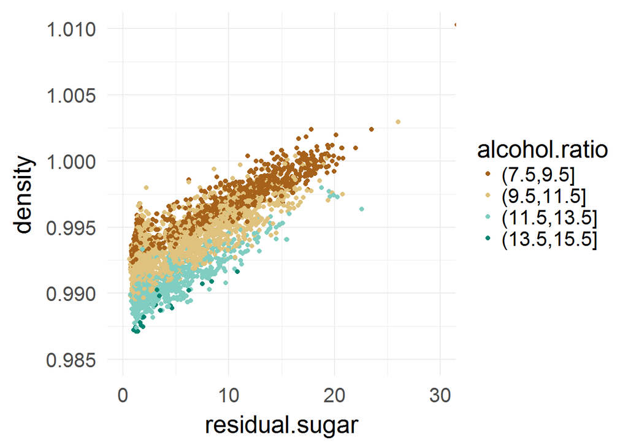

### Description Three

通过相关关系计算，发现密度和质量维持一种负相关关系，但是密度和残糖量、酒精存在相关性。酒精含量越大，密度越小，然后酒精含量越大，质量越大。 因此我们可以发现密度和质量两个变量之间不存在相关性，酒精变量的作用导致出现了表面上的相关性。

# Reflection

1.我们发现酒中的酸度和pH的存在相关性，但是并不是特别显著。pH值反映的就是液体的酸碱度，应该会出现很大的相关性。 但是根据分析结果，有点惊讶，相关系数只有-0.43，一个原因可能是观测值只有4898个，偏少；另一个原因是异常值对结果的影响。

2.该数据集中，存在多个变量之间存在相关性，比如free.sulfur.dioxide和total.sulfur.dioxide，其中容易误导分析方向就是density,表面上和quality 存在相关性，其实不然。

3.数据集中，质量评分结果是根据人的感觉进行评分，存在主观因素，导致对最终的结果会有偏差。因此我们在建立线性回归模型的时候，难度很大， 最终没能完成有效的回归模型。